# Lesson 2: The Statistical Process & Design of Studies

## Lesson Outcomes

Show/Hide Outcomes

## Introduction

Statistics are used in every aspect of society. Every statistical analysis follows a pattern we will call the Statistical Process. This process will be introduced in this lesson and will be used throughout the course.

### The Statistical Process and Daniel’s Experiment

[figure not shown]

Stained-glass depiction of Daniel’s deliverance from the lions’ den. Found in the old Dominican priory church at Hawkesyard in Staffordshire, England. (Photo credit: Fr Lawrence Lew, O.P. Used by permission.)

The Old Testament prophet Daniel planned one of the earliest recorded scientific research studies. We will use his example to illustrate the following five steps of The Statistical Process.

The following icons can help you remember these steps. Notice that each icon has a letter and an image to help you remember the five steps of the Statistical Process.

| The Statistical Process |  |
| --- | --- |
|  | **D**esign the Study |
|  | **C**ollect the Data |
|  | **D**escribe the Data |
|  | **M**ake Inference |
|  | **T**ake Action |

### Step 1: Design the Study

An important step in scientific inquiry or problem solving can be to state a research question such as:

- Will internet advertising increase a company’s revenue?
- Does expressing gratitude increase a person’s satisfaction with life in general?
- Does a newly developed vaccine prevent the spread of disease?

Researchers also investigate the background of the situation. What have other people discovered about this situation? How can we find the answer to the research question? What do we need to do? What is the **population** (or total collection of all individuals) under consideration? What kind of data need to be collected?

Before collecting data, researchers make a hypothesis, or an educated guess about the outcome of their research. A hypothesis is a statement such as the following:

- Using internet advertising will increase the company’s sales revenue.
- People who express gratitude will be more satisfied with life than those who do not.
- A newly-developed vaccine is effective at preventing tuberculosis.

#### Daniel’s Experiment

After taking Israel captive, Babylon’s King Nebuchadnezzar asked his chief officer to bring Israelite children who were well favoured, and skilful in all wisdom, and cunning in knowledge, and understanding science to stand in the king’s palaces [(Daniel 1:4)](https://www.churchofjesuschrist.org/scriptures/ot/dan/1.4?lang=eng#3). To aid their preparation, Nebuchadnezzar planned to feed them his meat and wine for three years [(Daniel 1:5)](https://www.churchofjesuschrist.org/scriptures/ot/dan/1.5?lang=eng#4).

Daniel did not want to defile himself by partaking of the king’s meat and wine. He asked permission to eat pulse[^1] and drink water instead. His supervisor, Melzar, was afraid to displease the king. He thought that after eating pulse and water, the selected Israelites would look worse than their peers, and he would be punished [(Daniel 1:8-10)](https://www.churchofjesuschrist.org/scriptures/ot/dan/1.8-10?lang=eng#3).

With an understanding of the background of the situation, Daniel proposed an experiment. He said, Prove thy servants, I beseech thee, ten days; and let them give us pulse to eat, and water to drink. Then let our countenances be looked upon before thee, and the countenance of the children that eat of the portion of the king’s meat: and as thou seest, deal with thy servants [(Daniel 1:12-13.)](https://www.churchofjesuschrist.org/scriptures/ot/dan/1.12-13?lang=eng#3). In short, Daniel’s implied research question can be stated as: Will those who eat pulse and drink water appear healthier than those who eat the king’s meat and drink his wine? Melzar agreed to the experiment.

Answer the following question:

1. What is Daniel’s hypothesis?

Show/Hide Solution

### Step 2: Collect Data

When designing a study, much attention is given to the process by which data are observed. When examining data, it is also important to understand the data collection procedures. A **sample** is a subset (a portion) of a population. How is this sample obtained? How are the observations made?

Daniel’s study design required that data be collected at the end of 10 days. Melzar would compare the appearances of two groups of people: (1) Israelites who ate pulse and drank water versus (2) Israelites who ate the king’s meat and drank his wine.

### Step 3: Describe the Data

When we describe data, we use any tools appropriate to the situation. This can include creating graphs or calculating statistics to help understand or visualize the data.

For Daniel’s experiment, the data are described in [Daniel 1:15](https://www.churchofjesuschrist.org/scriptures/ot/dan/1.15?lang=eng#3): And at the end of ten days [the] countenances [of those who ate pulse] appeared fairer and fatter in flesh than all the children which did eat the portion of the king’s meat.

### Step 4: Make Inferences

Inference is the process of using the information contained in a sample from a population to make a general statement (i.e. to infer something) about the entire population. Later in the course we will learn techniques that make this type of analysis possible.

Melzar made an inference. Based on the results of the sample, he determined that (in general) those who eat pulse and drink water will be healthier than those who eat the king’s meat and drink his wine [Daniel 1:15-16](https://www.churchofjesuschrist.org/scriptures/ot/dan/1.15-16?lang=eng#3).

### Step 5: Take Action

The goal of a statistical analysis is to determine which action to take in a particular situation. Actions can include many things: launching an internet ad campaign (or not), expressing gratitude (or not), getting vaccinated (or not), etc.

Melzar took action as described in [Daniel 1:16](https://www.churchofjesuschrist.org/scriptures/ot/dan/1.16?lang=eng#3): Thus Melzar took away the portion of their meat, and the wine that they should drink; and gave [all the Israelite children] pulse.

Was the experiment a success?

“Now at the end of the days that the king had said he should bring them in… the king communed with them; and among them all was found none like Daniel, Hananiah, Mishael, and Azariah And in all matters of wisdom and understanding, that the king enquired of them, he found them ten times better than all the magicians and astrologers that were in all his realm” [Daniel 1:18-20](https://www.churchofjesuschrist.org/scriptures/ot/dan/1.18-20?lang=eng#3).

### Summary of the Statistical Process

Daniel’s experience can also help you learn the Statistical Process. Look at the first letter of each of the steps in the Statistical Process. You can use the phrase “Daniel Can Discern More Truth” to help you to help you remember the five steps in the Statistical Process.

**The Statistical Process**

|  | Pneumonic | Actual Process Step |
| --- | --- | --- |
| Step 1: | **D**aniel | **D**esign the study |
| Step 2: | **C**an | **C**ollect data |
| Step 3: | **D**iscern | **D**escribe the data |
| Step 4: | **M**ore | **M**ake inferences |
| Step 5: | **T**ruth | **T**ake action |

The Statistical Process will be used throughout the course. Take time to memorize the five steps.

The study designed by the Old Testament prophet Daniel provides an ancient example of a designed experiment. Daniel’s experiment included two groups of people: those who had the experimental treatment eating pulse and drinking water (called the **treatment** group) and those who ate the standard food the king’s meat (called the **control** group.) The treatment group receives the experimental procedure. The control group is used for comparison.

Answer the following question:

2. Why was it important that Daniel’s experiment included a control group?

Show/Hide Solution

## Design of Studies

Most research projects can be classified into one of two basic categories: observational studies or designed experiments. In an **experiment**, researchers control (to some extent) the conditions under which measurements are made. In an **observational study**, researchers simply observe what happens, without controlling the conditions under which measurements are made. Both types of study follow the five steps of the Statistical Process.

### Designed Experiments

In a **designed experiment**, researchers manipulate the conditions that the participants experience. They often do this by randomly assigning subjects to one of two groups, a “treatment” group and a “control” group. The experiment is conducted by applying some kind of treatment to the subjects in the treatment group and observing the effect of the treatment. Those in the control group do not receive the treatment and are also observed. In this way researchers can determine the effects of the treatment. The following example illustrates the use of these two groups.

**Jonas Salk’s First Polio Vaccine Trial**

Beginning around 1916 and through the 1950s, a mysterious plague attacked infants and children. Symptoms included excruciating muscle pain and a stiff neck. This illness, which became known as poliomyelitis or simply “polio,” left children disfigured, paralyzed, and sometimes even dead.

While working as a researcher at the University of Pittsburgh School of Medicine, Dr. Jonas E. Salk developed a vaccine that might help prevent the spread of this disease. He conducted what has become one of the most famous designed experiments in history.

This short video below provides a compelling summary of the famous Jonas Salk vaccine experiment. As you watch, notice each of the 5 steps of a statistical study in this study.

[video not shown]

As explained in the video, in the first Salk trial almost 1.1 million children participated in the study. Even though the sample size was large, flaws in the study design rendered the results useless.

Undaunted, Dr. Salk fixed the problems with the design and enrolled hundreds of thousands of additional children for the second phase of his study. In all, over 1.8 million infants and children participated in this experiment, making it the largest drug trial to date.

**Step 1: Design the study.**

The participants in a study are commonly called subjects. Sometimes subjects are called experimental units or simply units. In the Salk trials, the children who participated were the subjects.

Subjects (the children) were randomly assigned to one of two groups. The first group was given the experimental vaccine, the treatment. The treatment is the new or experimental condition that is imposed on the subjects. The subjects who receive the treatment make up the treatment group.

The second group was given a control or placebo. In this study, the control was an injection that looked just like the vaccine, but contained a harmless saline solution. The control group or placebo group is made up of the subjects assigned to receive the control.

This study was double blind. Neither the children’s parents nor their doctors knew whether a particular child received the treatment or the control. Both parties were blinded to this information.

Because the children were assigned to the groups randomly, the two groups should be similar. If the vaccine is not effective, the number of future cases of polio should be about the same in each group. However, if Salk’s vaccine helped to prevent the spread of polio, then fewer cases should occur in the vaccinated group.

Answer the following questions:

3. Some children can be identified as having a higher risk of developing polio. Would it have been better if they were assigned to the treatment group so they could get the vaccine?

Show/Hide Solution

4. Why is it important for the subject and those who assess the health of the subject to be unaware of whether or not that child received the vaccine?

Show/Hide Solution

**Step 2: Collect data.**

The researchers followed up with each child to determine if they contracted polio. They recorded the number of children in each group that developed polio during the study period. Not all of Salk’s experiments were double-blind. Here is a summary of the results from the regions where a double-blind study was conducted (Francis et al., 1955; Brownlee, 1955):

**Children Who Developed Polio**

|  | Yes | No | Total |
| --- | --- | --- | --- |
| Treatment Group | 57 | 200,688 | 200,745 |
| Placebo Group | 142 | 201,087 | 201,229 |

**Step 3: Describe the data.**

One way to summarize the data is to compute the proportion of children in each group that developed polio. The proportion of children in the treatment group that developed polio during the study period is:

$$\frac{57}{200745} = 0.000~283~9$$

Answer the following questions:

5. Calculate the proportion of children in the placebo group that developed polio during the study period.

Show/Hide Solution

6. Compare the two proportions. What do you observe?

Show/Hide Solution

**Step 4: Make inferences**

Careful statistical analysis of the records suggested that this difference was so great that it was attributable to the vaccine and not to chance. Assuming that the vaccine had no effect, the probability that the difference in the proportions between the two groups would be at least as extreme as the difference Dr. Salk observed was very low: 0.00000000093. Because this probability is so small, it is highly unlikely that these results are due to chance.

**Step 5: Take action**

Once it was clear that the vaccine was effective, children who were unvaccinated or had received the placebo were given Salk’s vaccine. Since 1954, there has been a marked decrease in the number of polio cases worldwide (Offit, 2005). Public health researchers are striving to eradicate this disease entirely.

### Observational Studies

In an **observational study** researchers observe the responses of the individuals, without controlling the conditions experienced by the individuals. Therefore, they do not assign the participants to treatment or control groups.

Observational studies commonly occur in business settings. One example is a financial audit. The purpose of a financial audit is to assess the accuracy of a company’s financial business practices. ImmunAvance Ltd., a non-government health care organization, hired the Accounting Office at Global Optimization Unlimited to perform an independent audit of their financial practices. ImmunAvance provides inoculation and other preventative health care services in rural African communities.

**Step 1: Design the study**

The volume of financial transactions conducted by ImmunAvance makes it impossible to conduct a **census** or an examination of the entire collection of ImmunAvance’s financial documents. Instead, you will collect a manageable group of items (called the **sample**) from the entire collection of financial documents (called the **population**.) A sample is a subset or a portion of a population. The information gained from the sample is used to make an **inference** (or generalization) about the population.

Auditors typically cannot consider every item in a population, because there are too many. When it is not possible to conduct a census, auditors face **sampling risk**. Sampling risk is the risk affiliated with not auditing every item in the population. It is the risk that the sample may not adequately reflect the population. The only way to eliminate sampling risk is to conduct a census, which is usually not practical. Auditors can reduce sampling risk by obtaining a sample randomly. This is called **random selection**. Another way to reduce sampling risk is to increase the **sample size**, the number of items sampled.

### Sampling Methods

**Step 2: Collect data**

There are several procedures that can be used to select a random sample from a population, including: **simple random** sampling (SRS), **stratified** sampling, **systematic** sampling, **cluster** sampling, , and **convenience** sampling (or, haphazard sampling). These are examples of **sampling methods**.

#### Random Sampling Methods

A **simple random sample (SRS)** is the best method for obtaining a sample from a population. This method allows each possible sample of a certain size an equal chance at being selected as the chosen sample. A difficulty of this method is that a list of all of the items in the population must be accessible before the sample is taken. Often, we obtain a SRS by allowing a computer to randomly select a certain number of items from the full list of the population. It is akin to the idea of putting all of the names into a hat, shaking them up, and randomly drawing out a few.

For example, suppose there are 18,000 students in the population of a certain university. School officials can use a computer to randomly choose values between 1 and 18,000 to identify which students are to be selected to complete a survey. In Excel, the command to obtain a random number between 1 and 18,000 is =*RANDBETWEEN(1,18000)*. A simple random sample can be obtained any time there is a complete list of the items to be sampled and they are all accessible. All the statistical procedures in this course assume that simple random sampling has been used. But in practice, the SRS is often difficult (or impossible) to implement.

A **stratified sample** is when the items to be sampled are organized in groups of homogeneous (similar) items called strata, then a simple random sample is drawn from each of these strata. Stratified sampling works well when the items are similar within each stratum and tend to differ from one stratum to another. We often use stratified sampling in order to obtain a sample in such a way that we can make comparisons between each of the groups (or strata).

For example, in obtaining a sample of students from a university, school officials could define the strata as: (1) freshman, (2) sophomores, (3) juniors, and (4) seniors. A simple random sample could then be obtained from each of these strata. This would ensure that each class rank of students was represented in the sample. It would also allow the school officials to see how freshman, sophomore, junior, and senior level students compared in their answers to a survey.

A **systematic sample** is where every $k^{\text{th}}$ item in the population is selected to be part of the sample, beginning at a random starting point. Systematic sampling works well when the items are in a random, but sequential ordering. If the items are not arranged randomly, a systematic sample can miss important parts of the population.

For example, consider a fast food company where every 10th customer is given the opportunity to compete a satisfaction survey in exchange for a small discount coupon towards their next purchase. An airport security line also often implements a procedure where every 100th (or so) person is selected for a more “in depth” security examination. Similarly, factories that use assembly lines will pull say every 500th item from the assembly line to perform a quality control check on the item.

A **cluster sample** (sometimes called a *block sample*) consists of taking all items in one or more randomly selected clusters, or blocks. When the variation from one block to another is relatively low, compared to the variation within the block, cluster sampling is a reasonable way to get a sample.

For example, ecologists could draw grids on a map of a forest to create small sampling regions, or sampling clusters. Then, by randomly selecting one or two of these clusters from the map, the ecologists could go to the areas marked on the map and document information on the health of every tree they find in those clusters. This is a practical way to get a sample in this case because the ecologists only have to go to a few areas of the forest, but are still able to obtain a random sample of all of the trees in the forest. It is also worth noting that the ecologists would not be interesting in comparing the health of the trees from the selected clusters to each other like they would in a stratified sample. Instead, they are just looking for a feasible way to obtain a single random sample of all of the trees in the forest, but want to keep their traveling time to a minimum while collecting their sample. In contrast, to obtain a simple random sample of trees from the same forest, the ecologists would first have to go out and number every tree in the entire forest. Then they would need to use a computer to randomly pick which trees to collect data on. Finally, they would then have to go back to the forest and collect data on the selected trees from across the entire forest. Such an approach just isn’t feasible in practice, so we are willing to settle instead for the cluster sample.

A **convenience sample** involves selecting items that are relatively easy to obtain and does not use random selection to choose the sample. This method of sampling can be assumed to always bring bias into the sample.

As an example of a convenience sample, an auditor could haphazardly select items from a filing cabinet. This is frequently done when a quick and simple sample is needed, but may not yield a sample that represents the population well. When possible, convenience samples **should be avoided.**

### Types of Variables

Whenever we collect data, we record information about the things we are studying. There are two basic types of data that can be recorded: quantitative measurements and categorical labels. We will call these types of data simply “quantitative” or “categorical” variables. We use the word “variable” to denote the idea that the quantitative measurements or categorical labels can vary from person to person, or item to item, in our study.

**Quantitative variables** provide measurement information on each individual (or item) in our study. They represent things that are numeric in nature; things that are measured. They often include units of measurement along with the quantitative value of the measurement. For example, the heights of children measured in inches (or centimeters), or their weight measured in pounds (or kilograms). For a quantitative variable, it makes sense to apply arithmetic operations to the data (such as adding values together, computing the average of the values, or comparing two values). If one child weighs 30 pounds (13.61 kg) and a second child weights 60 pounds (27.22) then the second child is twice as heavy as the first.

**Categorical variables** allow us to place each individual (or item) into to a specific category. Categorical variables are labels, and it does not make sense to do arithmetic with them. For example the gender of a newborn child, the ethnicity of an individual, a person’s job title, the brand of phone they own, or the area code of a telephone number, etc are all categorical variables. Notice that although a telephone number consists of numbers, it is not a quantitative measurement. It does not make sense to double someone’s phone number, to average phone numbers together, or to say one phone number is half the size of another. But the area code of the phone number gives information about the region where the phone number was first initiated, which is categorical information.

In Unit 3 of this course we will learn more about categorical variables and proportions. Units 1 and 2 of this course focus on studying quantitative variables.

Answer the following question:

Show/Hide Solution

2. Account number

Show/Hide Solution

3. Invoice amount

Show/Hide Solution

**Step 3: Describe the data**

After auditors collect a sample and compile the data, they review the evidence. Auditors may use graphs or compute numbers (such as the average) to summarize the evidence they found.

## Making Inferences: Hypothesis Testing

**Step 4: Make inferences**

Auditors use the information drawn from the sample to form an opinion about the population. Whenever sample data is used to infer a characteristic of a population, it is called making an inference. **Inferential statistics** represents a collection of methods that can be used to make inference about a population. Based on the documents reviewed, the auditors assess if the company is conducting its business in a proper manner.

When conducting an audit, the implicit assumption is that transactions have been posted properly. As auditors sample the company’s records, they are looking to see if everything is consistent with the original assumption that all transactions have been posted properly. It would only be in the case of discovering suspicious activity or evidence of fraudulent reporting that the auditors would change their belief about the company and accuse the company ImmunAvance of falsely reporting on their financial statements.

“Piled Higher and Deeper” by Jorge Cham

[figure not shown]

There is a formal procedure for determining when *enough* evidence has been found to make accusations of fraud. Later this semester, after we establish some foundational principles of statistics, we will study these statistical methods in depth. Of course, these methods can be used for much more than just determining if a company has reported their financial statements fraudulently. So we will look at many different ways these statistical procedures can be applied to research and industry.

For ImmunAvance’s audit, based on the samples of financial statements that had been selected, while there were a few errors in the documents, there was not evidence dramatic enough to claim that the company had been fraudulent. So the company passed their audit.

**Step 5: Take Action**

The auditors prepare a report in which they give their opinion on the status of the company’s current operations.

Since there was not enough evidence to suggest that ImmunAvance’s financial statements were fraudulent, the auditor’s conclusion is that no adjustment is necessary. The few observed discrepancies were apparently just the result of random chance errors, not the deliberate falsefying of information.

## Introduction to R and RStudio

### Data Types in R

R Instructions

Show/Hide R Instructions

There are many data types in R. In this course, we will use two data types: vectors and data frames.

#### Vectors in R

```r
mydata <- c(1, 1, 2, 3, 5, 8)
```

It may not seem like anything happened, but you can see your variable in the Environment pane (the upper-right corner of the RStudio screen).

If you type the variable name in the Console area and press Enter, RStudio will display the contents of the variable.

```r
mydata
```

```
## [1] 1 1 2 3 5 8
```

Let’s explore the command we used to create the vector `mydata`.

```r
mydata <- c(1, 1, 2, 3, 5, 8)
```

There are four important elements here. We will investigate them from right to left.

1. First, consider the values we want to store in the vector: `1, 1, 2, 3, 5, 8`. These numbers are given in an order that they will appear in the vector.
2. Next, we use the combine (or concatentate) function, `c(...)` to join the six individual numbers together as one vector. The values in the parentheses are the values that will appear in the vector.
3. Then, we use the “assignment operator” which is denoted as `<-` to indicate that we are going to take the value on the right and give it the name listed to the left. It is easy to remember, because it looks like a backwards arrow moving the information on the right into the variable name on the left.
4. Finally, we state the name of our vector: `mydata`. This allows us to use this vector later.

Vectors can have numeric `(3.14159, 6, -7.02, ...)` or character `("a", "hello", "world", ...)` values. All the values in a vector must have the same type.

#### Data Frames in R

The data type we will most frequently use is a **data frame**. This is basically a collection of vectors. (Think about a frame keeping these vectors of data together.)

Typically, we will create data frames by reading data in from a file. To illustrate that a data frame is just a collection of vectors, copy and paste the following code into the Console. (We typically use lower-case letters for R variable names and separate words with an underscore `_`.)

```r
name <- c("Abigail", "Benjamin", "Cleopas", "Deborah", "Esther")
gender <- c("Female", "Male", "Male", "Female", "Female")
age <- c(28, 27, 22, 25, 27)
height_cm <- c(153, 175.5, 166.75, 167, 142.25)
mydata2 <- data.frame(name, gender, age, height_cm)
```

By pasting these commands in the Console and pressing Enter, you have created five new variables in R. They will be displayed in the Environment pane (in the upper-right portion of the RStudio window).

Notice that the vectors are listed together under “Values,” and the data frame `mydata2` is listed separately in the “Data” area above.

If you click on `mydata2` in the Environment pane, this data frame will be displayed in the upper-left corner of the RStudio window.

Look in the Console pane. You will notice that when you clicked on `mydata2`, RStudio executed the following command in the Console.

```r
View(mydata2)
```

You can use this shortcut any time you want to view the full data frame.

### Accessing a Vector in a Data Frame

R Instructions

Show/Hide R Instructions

If you want to quickly see what is in a data frame, just enter the name of the data frame in the Console:

```r
mydata2
```

```
##       name gender age height_cm
## 1  Abigail Female  28    153.00
## 2 Benjamin   Male  27    175.50
## 3  Cleopas   Male  22    166.75
## 4  Deborah Female  25    167.00
## 5   Esther Female  27    142.25
```

However, if you want to work with just one vector from this data frame, we use the `$` (dollar sign) operator. To access the vector `height_cm` contained in the data frame `mydata2`, enter the following in the Console:

```r
mydata2$height_cm
```

```
## [1] 153.00 175.50 166.75 167.00 142.25
```

Notice that if you start typing `mydata2` in the console, after about three characters, RStudio will give you suggestions of how you might finish your expression. From the drop-down list that appears, choose `mydata2`. Then, type the $ sign. A drop-down list will appear showing all the variables in that vector. Use up- or down-arrows to choose `height_cm` from the drop-down list. Notice that RStudio then completes your expression. If you press enter, RStudio will display the values stored in that vector.

### Computing an Average (i.e. Mean) using R

R Instructions

Show/Hide R Instructions

To find the average of a set of values, the R command is `mean(...)`. As you will discover in the next lesson, statisticians use the word “mean” to describe what many people call the “average”.

We can compute the mean (or average) of a vector of values by giving the name of the vector as the argument to the function `mean()'. The argument for the function`mean()` (i.e. the thing you put in parentheses) needs to be a vector.

```r
mean(height_cm)
```

```
## [1] 160.9
```

This command is using the vector of values that we called `height_cm` just before the data frame `mydata2` was created.

Now, we will compute the mean of the vector `height_cm` contained in the dataframe `mydata2`:

```r
mean(mydata2$height_cm)
```

```
## [1] 160.9
```

Notice that in both cases, we have computed the mean of a vector. These are different vectors. Usually, we will be accessing data stored in a data frame, so we will almost always use the latter method.

### Comments in R

R Instructions

Show/Hide R Instructions

Sometimes you may want to make a note to yourself to remind you about something related to your code. If you place the `#` symbol at the beginning of a line in your R commands, R will not run that command. This is called a comment. When R evaluates code, it skips over each comment and goes to the next line.

```r
# This is a comment
```

### Reading Data into R

R Instructions

Show/Hide R Instructions

**Here are two methods for reading data into R:**

**Method 1: Specify the data values explicitly**

This is the process we followed in the examples above.

```r
# Define a vector of six values called mydata
mydata <- c(1, 1, 2, 3, 5, 8)

# Define additional vectors with five values each
name <- c("Abigail", "Benjamin", "Cleopas", "Deborah", "Esther")
gender <- c("Female", "Male", "Male", "Female", "Female")
age <- c(28, 27, 22, 25, 27)
height_cm <- c(153, 175.5, 166.75, 167, 142.25)

# Combine the four vectors into a data frame called mydata2
mydata2 <- data.frame(name, gender, age, height_cm)
```

This works well if you have a very small data set. Usually, we have a large data set and will need to read it in from a file.

**Method 2: Read in data from a file**

To read in a data file in R, do the following:

- Read in the dataset. For this example, open the data file by right clicking on this link: surgery_lawsuits.xlsx and then selecting “Copy link address”.
- In RStudio, select the “Environment” window, click on “Import Dataset”, and then choose “From Excel…” from the menu that appears. Like this:

[figure not shown]

- Paste the copied link for the data into the “File/URL:” box and click “Update”. The data should pull up in the “Data Preview:” window. If it looks like it worked, click “Import” to import the data into RStudio.

[figure not shown]

- We can calculate the average (mean) of any quantitative column of the data frame `surgery_lawsuits` using the `mean(...)` function and the selection operator `$` as follows. If we want the mean of the `wrong_site` column, we enter the following in the Console:

```r
mean(surgery_lawsuits$wrong_site)
```

```
## [1] 80041.24
```

Note: as soon as you type in the name of the data set, `surgery_lawsuits`, and then add the selection operator `$` (a dollar sign) to the end of the data set, you are able to access any column from that dataset. (Think of it as “buying an item” from a dataset with “your money: `$`.”)

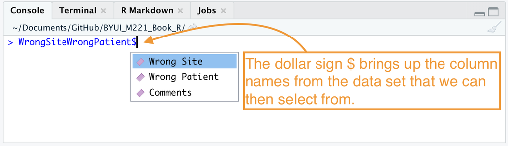

Now, try computing the mean of the `wrong_patient` data.

## Summary

Remember…

- The **Statistical Process** has five steps: **D**esign the study, **C**ollect the data, **D**escribe the data, **M**ake inferences, **T**ake action.
- In a **designed experiment**, researchers control the conditions of the study. In an **observational study**, researchers don’t control the conditions but only observe what happens.
- There are many sampling methods used to obtain a **sample** from a **population**:
  - A **simple random sample (SRS)** is a random selection taken from a population
  - A **systematic sample** is every *k*<sup>th</sup> item in the population, beginning at a random starting point
  - A **cluster sample** is all items in one or more randomly selected clusters, or blocks
  - A **stratified sample** divides data into similar groups and an **SRS** is taken from each group
  - A **convenience sample** is one easily obtained in a less-than-systematic way and should be avoided whenever possible
- **Quantitative variables** represent things that are numeric in nature, such as the value of a car or the number of students in a classroom. **Categorical variables** represent non-numerical data that can only be considered as labels, such as colors or brands of shoes.

## References

Bible Dictionary, “Pulse” at http://churchofjesuschrist.org/scriptures/bd/pulse.

Brownlee, K. A. (1955). Statistics of the 1954 polio vaccine trials. Journal of the American Statistical Association, 50(272), pp. 1005-1013.

Francis, T., et. al. (1955). An evaluation of the 1954 poliomyletis vaccine trials. American Journal of Public Health and the Nation’s Health, 45(5)

Offit, P. A. (2005). Why are pharmaceutical companies gradually abandoning vaccines? Health Affairs, 24(3), 622-630. [doi:10.1377/hlthaff.24.3.622](https://www.healthaffairs.org/doi/full/10.1377/hlthaff.24.3.622)

## Additional Reading

Sampling Chapter.pdf

## Navigation

| **Previous Reading** | **This Reading** | **Next Reading** |
| --- | --- | --- |
| Lesson 1: Course Intro & Probability | Lesson 2: The Statistical Process & Design of Studies | Lesson 3: Describing Quantitative Data (Shape & Center) |

[^1]: [churchofjesuschrist.org definition of pulse](http://www.churchofjesuschrist.org/scriptures/bd/pulse?lang=eng&query=pulse)